# R Notebook

Cargamos la data de todos los partidos de 2017-2018 y hacemos primeros análisis exploratorio. La descarga proviene de raw_generate_seasonal_2017_2018_regular.R

```r
seasonal_games <- readRDS(file = here::here("data","raw","seasonal_games_2017_2018.RDS"))
```

```r
attributes(seasonal_games$api_json)
```

```
$`names`
[1] "lastUpdatedOn" "games"         "references"
```

```r
# attributes(seasonal_games$api_json$games) # datos partido
attributes(seasonal_games$api_json$references$venueReferences) # meta de equipos y estadio
```

```
$`names`
 [1] "id"                    "name"                  "city"                  "country"
 [5] "geoCoordinates"        "capacitiesByEventType" "playingSurface"        "baseballDimensions"
 [9] "hasRoof"               "hasRetractableRoof"

$class
[1] "data.frame"

$row.names
 [1]  1  2  3  4  5  6  7  8  9 10 11 12 13 14 15 16 17 18 19 20 21 22 23 24 25 26 27 28 29
```

EDA de games

```r
games_raw <- seasonal_games$api_json$games
games_raw$score.quarters[[1]]
```

|  | quarterNumber | awayScore | homeScore |
| --- | --- | --- | --- |
| 1 | 1 | 19 | 29 |
| 2 | 2 | 19 | 25 |
| 3 | 3 | 33 | 18 |
| 4 | 4 | 28 | 30 |

```r
# glimpse(games_raw)
games <- games_raw %>% select(game_id = schedule.id , game_start_time = schedule.startTime,
                              away_team = schedule.awayTeam.abbreviation,
                              home_team = schedule.homeTeam.abbreviation,
                              away_score = score.awayScoreTotal,
                              home_score = score.homeScoreTotal,
                              quarters_score = score.quarters)
# glimpse(games)
games %>% select(-quarters_score) %>% summary()
```

```
    game_id      game_start_time     away_team          home_team           away_score      home_score
 Min.   :42070   Length:1230        Length:1230        Length:1230        Min.   : 69.0   Min.   : 69.0
 1st Qu.:42384   Class :character   Class :character   Class :character   1st Qu.: 97.0   1st Qu.: 99.0
 Median :42695   Mode  :character   Mode  :character   Mode  :character   Median :105.0   Median :107.0
 Mean   :42693                                                            Mean   :105.3   Mean   :107.4
 3rd Qu.:43002                                                            3rd Qu.:113.0   3rd Qu.:115.0
 Max.   :43400                                                            Max.   :148.0   Max.   :149.0
```

1230 partidos. 82 fechas * 30 equipos. (dividido 2)

Home vs Away

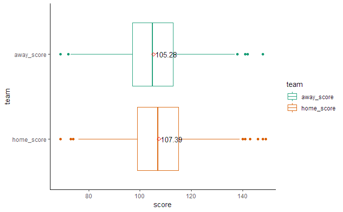

```r
means <- games %>% summarise(away = mean(away_score),home = mean(home_score)) %>% as.matrix() %>% as.vector() %>%
  round(2)
games_stack <- games %>% select(-quarters_score) %>%
  gather(key = team, value = score, 5:6 )
games_stack %>%
  # arrange(game_id) %>%
  ggplot(aes(x = team, y = score, color = team)) +
  geom_boxplot() +
  coord_flip() +
  stat_summary(fun.y = mean, geom = "point", color = "red", shape = 5) +
  scale_color_brewer(palette = "Dark2") +
  theme_classic() +
  scale_x_discrete(limits = c("home_score", "away_score")) +
  stat_summary(fun.y = function(x) mean(x) + 5 , geom = "text", label = means, color = "black")
```

Puntos hechos por partido

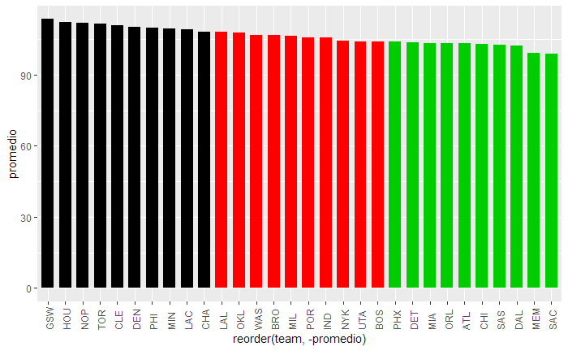

```r
t1 <- games_stack %>% filter(team == "away_score") %>%
  select(-c(home_team,team)) %>%
  rename(team = away_team)

t2 <- games_stack %>% filter(team == "home_score") %>%
  select(-c(away_team,team)) %>%
  rename(team = home_team)

t3 <- rbind(t1,t2)
# Barchart estandar
t3 %>% group_by(team) %>%
  summarise(total = sum(score), promedio = mean(score), desvio = sd(score)) %>%
  arrange(promedio) %>%
  ggplot(aes(x = reorder(team, -promedio), y = promedio)) +
  geom_col(width = 0.7, fill = c(rep(1,10), rep(2,10), rep(3,10))) +
  theme(axis.text.x = element_text(angle = 90, hjust = 0, vjust = 0.6))
```

```r
  # coord_flip()
```

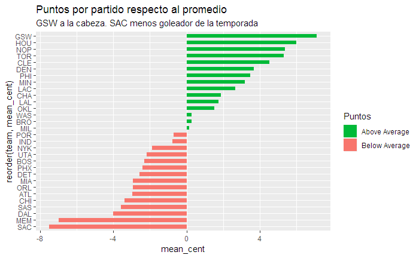

```r
# Diverging bars
t3 %>% group_by(team) %>%
  summarise(total = sum(score), promedio = mean(score), desvio = sd(score)) %>%
  mutate(type = ifelse(promedio > mean(t3$score),"above","below"), mean_cent = promedio - mean(t3$score)) %>%
  #arrange(promedio) %>%
  ggplot(aes(x = reorder(team, mean_cent), y = mean_cent)) +
  geom_bar(stat = "identity", aes(fill = type), width = 0.6) +
  scale_fill_manual(name="Puntos",
                    labels = c("Above Average", "Below Average"),
                    values = c("above"="#00ba38", "below"="#f8766d")) +
  labs(subtitle="GSW a la cabeza. SAC menos goleador de la temporada",
       title= "Puntos por partido respecto al promedio") +
  coord_flip()
```

Agregando Playoffs

```r
playoff_games <- readRDS(here::here("data","raw","playoff_games_2017_2018.rds"))
playoff_teams <- playoff_games$api_json$references[[1]]$abbreviation %>%
  as.data.frame() %>% rename(team = '.') %>% mutate(playoffs = 7) # 7 para que ya sirva como posicion en el plot. Hardcodeado
```

```r
t4 <- t3 %>% left_join(.,playoff_teams, by = "team")
```

```
Column `team` joining character vector and factor, coercing into character vector
```

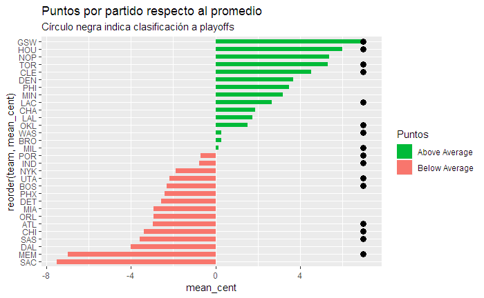

```r
t4 %>% group_by(team) %>%
  summarise(total = sum(score), promedio = mean(score), desvio = sd(score), playoffs = mean(playoffs)) %>%
  mutate(type = ifelse(promedio > mean(t4$score),"above","below"), mean_cent = promedio - mean(t4$score)) %>%
  #arrange(promedio) %>%
  ggplot(aes(x = reorder(team, mean_cent), y = mean_cent)) +
  geom_bar(stat = "identity", aes(fill = type), width = 0.6) +
  geom_point(aes(x = team, y = playoffs), size = 3) +
  scale_fill_manual(name="Puntos",
                    labels = c("Above Average", "Below Average"),
                    values = c("above"="#00ba38", "below"="#f8766d")) +
  labs(subtitle="Círculo negra indica clasificación a playoffs",
       title= "Puntos por partido respecto al promedio") +
  coord_flip()
```

En principio (temporada 2017-2018) parece que hacer mas puntos que la media no es garantía de Playoffs

Analizamos FG2 % y FG3 % vs Win %.

La consulta de team stats tiene bastante data a nivel temporada por equipo.

```r
team_stats <- readRDS(here::here("data","raw", "team_stats_2017_2018.rds"))
```

```r
team_stats_df <- team_stats$api_json$teamStatsTotals
# glimpse(team_stats_df)
```

Hay relación lineal entre Fg2 % y partidos ganados pero alrededor del 50% hay cierta variabilidad, como dos grupos con bastante diferencia de Win%.

Tendrá que ver los puntos permitidos o cantidad de posesiones?

<> Emprolijar

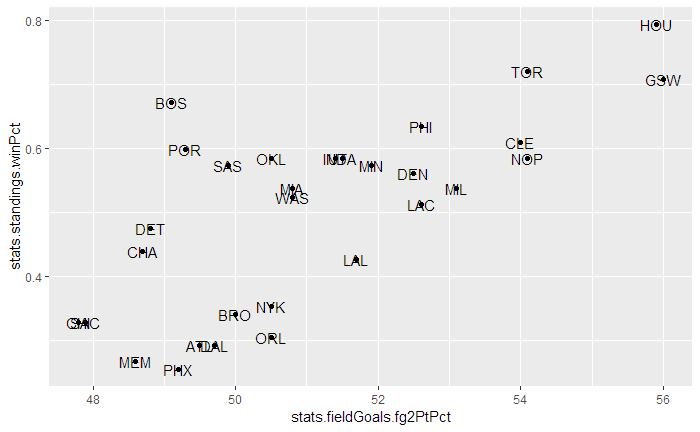

```r
fg2ptpct <- team_stats_df %>% select(team.abbreviation, stats.fieldGoals.fg2PtAttPerGame, stats.fieldGoals.fg2PtPct, stats.standings.winPct) %>%
  arrange(-stats.fieldGoals.fg2PtPct)
fg2ptpct %>% ggplot(aes(x = stats.fieldGoals.fg2PtPct, y = stats.standings.winPct, label = team.abbreviation)) +
  geom_point() +
  geom_text()
```

Hay relación creciente entre FG3 % y Win % pero no tan lineal. Esta el Outlier de SAC con buen porcentaje y poco Win % pero tiene pocos tiros comparados con el resto. Quitar? Correr regresión con weight por Attempts?

<> Emprolijar

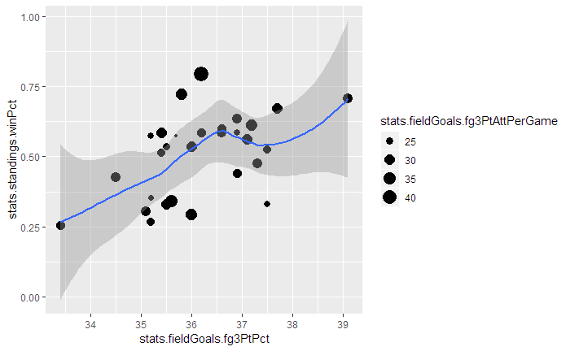

```r
fg3ptpct <- team_stats_df %>% select(team.abbreviation, stats.fieldGoals.fg3PtAttPerGame, stats.fieldGoals.fg3PtPct, stats.standings.winPct) %>%
  arrange(-stats.fieldGoals.fg3PtPct)
fg3ptpct %>% ggplot(aes(x = stats.fieldGoals.fg3PtPct, y = stats.standings.winPct, label = team.abbreviation)) +
  geom_point(aes(size = stats.fieldGoals.fg3PtAttPerGame)) +
  geom_smooth()
```

Correlaciones.

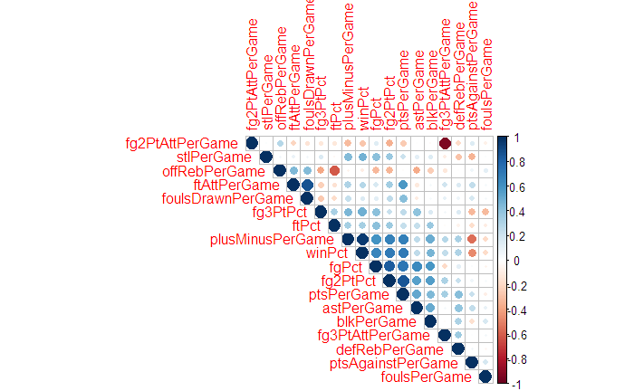

```r
temp <- team_stats$api_json$teamStatsTotals %>%
   select(team.abbreviation, stats.fieldGoals.fg2PtAttPerGame, stats.fieldGoals.fg2PtPct,stats.fieldGoals.fg3PtAttPerGame,    stats.fieldGoals.fg3PtPct,
          stats.fieldGoals.fgPct,
   stats.freeThrows.ftAttPerGame, stats.freeThrows.ftPct, stats.rebounds.offRebPerGame, stats.rebounds.defRebPerGame,         stats.offense.astPerGame,
   stats.offense.ptsPerGame, stats.defense.stlPerGame, stats.defense.blkPerGame, stats.defense.ptsAgainstPerGame,             stats.miscellaneous.foulsPerGame,
   stats.miscellaneous.foulsDrawnPerGame, stats.miscellaneous.plusMinusPerGame, stats.standings.winPct )
cor1 <- cor(temp[,-1])
rownames(cor1) <- stringr::word(rownames(cor1),-1, sep = "\\.")
colnames(cor1) <- stringr::word(colnames(cor1),-1, sep = "\\.")
corrplot::corrplot(cor1, method = "circle", type = "upper", tl.cex = 1, order = "hclust")
```

- Fg2Att correlaciona negativo con Fg3Att (logico, misma cantidad de tiros, distinta composicion)
- offReb correlaciona negativo con FTpct. Agarran más rebotes ofensivos los que erran los libres? OffReb no se da casi durante el juego dinámico? No sería un parámetro que aporta a ganar partidos .
- Fg2Pct correlaciona muy bien con WinPct.
- ptsPerGame correlaciona positivo con Win. Un poco contradictorio con el gráfico anterior de quienes entraro a playoffs.
- DefReb correlaciona positivo (aunque no fuerte) con ptsPerGame y WinPct (en chart vemos que hay una tendencia)
- Blks correlaciona positivo (aunque no fuerte) con ptsPerGame y WinPct. En chart vemos que está afectado por outliers. En WinPct es más lineal.

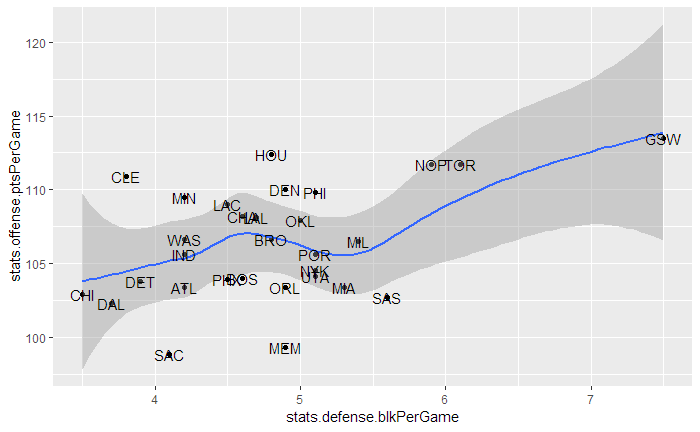

```r
temp %>% ggplot(aes(x = stats.defense.blkPerGame, y = stats.offense.ptsPerGame, label = team.abbreviation)) +
  geom_point() +
  geom_smooth() +
  geom_text()
```

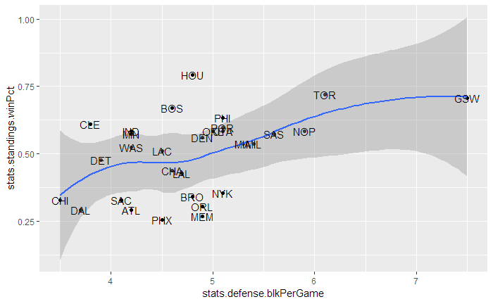

```r
temp %>% ggplot(aes(x = stats.defense.blkPerGame, y = stats.standings.winPct, label = team.abbreviation)) +
  geom_point() +
  geom_smooth() +
  geom_text()
```

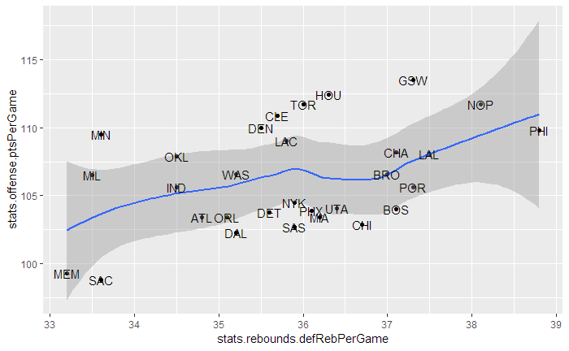

```r
temp %>% ggplot(aes(x = stats.rebounds.defRebPerGame, y = stats.offense.ptsPerGame, label = team.abbreviation)) +
  geom_point() +
  geom_smooth() +
  geom_text()
```

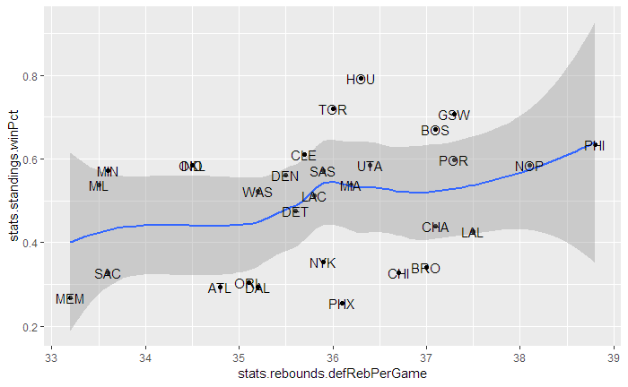

```r
temp %>% ggplot(aes(x = stats.rebounds.defRebPerGame, y = stats.standings.winPct, label = team.abbreviation)) +
  geom_point() +
  geom_smooth() +
  geom_text()
```